# JWST Pipeline Validation Notebook: NIRCam, calwebb_image3, source_catalog

Introduction  
JWST CalWG Algorithm  
Defining Terms  
Test Description  
Data Description  
Set up Temporary Directory  
Imports  
Loading the Data  
Run the Image3Pipeline  
Perform Visual Inspection  
Manually Find Matches  
About This Notebook

# Introduction

This is the NIRCam validation notebook for the Source Catalog step, which generates a catalog based on input exposures.

- Step description: https://jwst-pipeline.readthedocs.io/en/latest/jwst/source_catalog/index.html
- Pipeline code: https://github.com/spacetelescope/jwst/tree/master/jwst/source_catalog

Top of Page

# JWST CalWG Algorithm

This is the NIRCam imaging validation notebook for the Source Catalog step, which uses image combinations or stacks of overlapping images to generate "browse-quality" source catalogs. Having automated source catalogs will help accelerate the science output of JWST. The source catalogs should include both point and "slightly" extended sources at a minimum. The catalog should provide an indication if the source is a point or an extended source. For point sources, the source catalog should include measurements corrected to infinite aperture using aperture corrections provided by a reference file.

See:

- https://outerspace.stsci.edu/display/JWSTCC/Vanilla+Point+Source+Catalog

Top of Page

# Defining Terms

- JWST: James Webb Space Telescope
- NIRCam: Near-Infrared Camera

Top of Page

# Test Description

Here we generate the source catalog and visually inspect a plot of the image with the source catalog overlaid. We also look at some other diagnostic plots and then cross-check the output catalog against Mirage catalog inputs.

Top of Page

# Data Description

Top of Page

# Set up Temporary Directory

The following cell sets up a temporary directory (using python's `tempfile.TemporaryDirectory()`), and changes the script's active directory into that directory (using python's `os.chdir()`). This is so that, when the notebook is run through, it will download files to (and create output files in) the temporary directory rather than in the notebook's directory. This makes cleanup significantly easier (since all output files are deleted when the notebook is shut down), and also means that different notebooks in the same directory won't interfere with each other when run by the automated webpage generation process.

If you want the notebook to generate output in the notebook's directory, simply don't run this cell.

If you have a file (or files) that are kept in the notebook's directory, and that the notebook needs to use while running, you can copy that file into the directory (the code to do so is present below, but commented out).

```python
#****
#
# Set this variable to False to not use the temporary directory
#
#****
use_tempdir = True

# Create a temporary directory to hold notebook output, and change the working directory to that directory.
from tempfile import TemporaryDirectory
import os
import shutil

if use_tempdir:
    data_dir = TemporaryDirectory()

    # If you have files that are in the notebook's directory, but that the notebook will need to use while
    # running, copy them into the temporary directory here.
    #
    # files = ['name_of_file']
    # for file_name in files:
    #     shutil.copy(file_name, os.path.join(data_dir.name, file_name))

    # Save original directory
    orig_dir = os.getcwd()

    # Move to new directory
    os.chdir(data_dir.name)

# For info, print out where the script is running
print("Running in {}".format(os.getcwd()))
```

```
Running in /internal/data1/jenkins/workspace/Notebooks/jwst_validation_notebooks_spacetelescope/tmp/tmpktcl9j4u
```

Top of Page

```python
import os
if 'CRDS_CACHE_TYPE' in os.environ:
    if os.environ['CRDS_CACHE_TYPE'] == 'local':
        os.environ['CRDS_PATH'] = os.path.join(os.environ['HOME'], 'crds', 'cache')
    elif os.path.isdir(os.environ['CRDS_CACHE_TYPE']):
        os.environ['CRDS_PATH'] = os.environ['CRDS_CACHE_TYPE']
print('CRDS cache location: {}'.format(os.environ['CRDS_PATH']))
```

```
CRDS cache location: /grp/crds/cache
```

Top of Page

# Imports

List the package imports and why they are relevant to this notebook.

- astropy for various tools and packages
- inspect to get the docstring of our objects.
- IPython.display for printing markdown output
- jwst.datamodels for JWST Pipeline data models
- jwst.module.PipelineStep is the pipeline step being tested
- matplotlib.pyplot.plt to generate plot

```python
# plotting, the inline must come before the matplotlib import
%matplotlib inline
# %matplotlib notebook

# These gymnastics are needed to make the sizes of the figures
# be the same in both the inline and notebook versions
%config InlineBackend.print_figure_kwargs = {'bbox_inches': None}
import matplotlib.pyplot as plt
import matplotlib as mpl
mpl.rcParams['savefig.dpi'] = 80
mpl.rcParams['figure.dpi'] = 80

from matplotlib import pyplot as plt
import matplotlib.patches as patches

params = {'legend.fontsize': 6,
          'figure.figsize': (8, 8),
          'figure.dpi': 150,
         'axes.labelsize': 6,
         'axes.titlesize': 6,
         'xtick.labelsize':6,
         'ytick.labelsize':6}
plt.rcParams.update(params)

# Box download imports
from astropy.utils.data import download_file
from pathlib import Path
from shutil import move
from os.path import splitext

# python general
import os
import numpy as np

# astropy modules
import astropy
from astropy.io import fits
from astropy.table import QTable, Table, vstack, unique
from astropy.wcs.utils import skycoord_to_pixel
from astropy.coordinates import SkyCoord
from astropy.visualization import simple_norm
from astropy import units as u
import photutils

# jwst
from jwst.pipeline import calwebb_image3
from jwst import datamodels
```

```python
def create_image(data_2d, xpixel=None, ypixel=None, title=None):
    ''' Function to generate a 2D image of the data,
    with an option to highlight a specific pixel.
    '''

    fig = plt.figure(figsize=(8, 8))
    ax = plt.subplot()

    norm = simple_norm(data_2d, 'sqrt', percent=99.)

    plt.imshow(data_2d, norm=norm, origin='lower', cmap='gray')

    if xpixel and ypixel:
        plt.plot(xpixel, ypixel, marker='o', color='red', label='Selected Pixel')

    plt.xlabel('Pixel column')
    plt.ylabel('Pixel row')

    if title:
        plt.title(title)

    plt.subplots_adjust(left=0.15)
    plt.colorbar(label='MJy/sr')
```

```python
def create_image_with_cat(data_2d, catalog, flux_limit=None, title=None):
    ''' Function to generate a 2D image of the data,
    with sources overlaid.
    '''

    fig = plt.figure(figsize=(8, 8))
    ax = plt.subplot()

    norm = simple_norm(data_2d, 'sqrt', percent=99.)

    plt.imshow(data_2d, norm=norm, origin='lower', cmap='gray')

    for row in catalog:
        if flux_limit:
            if np.isnan(row['aper_total_flux']):
                pass
            else:
                if row['aper_total_flux'] > flux_limit:
                    plt.plot(row['xcentroid'], row['ycentroid'], marker='o', markersize='3', color='red')
        else:
            plt.plot(row['xcentroid'], row['ycentroid'], marker='o', markersize='1', color='red')

    plt.xlabel('Pixel column')
    plt.ylabel('Pixel row')

    if title:
        plt.title(title)

    plt.subplots_adjust(left=0.15)
    plt.colorbar(label='MJy/sr')
```

```python
def create_scatterplot(catalog_colx, catalog_coly, title=None):
    ''' Function to generate a generic scatterplot.
    '''

    fig = plt.figure(figsize=(8, 8))
    ax = plt.subplot()
    ax.scatter(catalog_colx,catalog_coly)
    plt.xlabel(catalog_colx.name)
    plt.ylabel(catalog_coly.name)


    if title:
        plt.title(title)
```

```python
def get_input_table(sourcelist):
    '''Function to read in and access the simulator source input files.'''

    all_source_table = Table()

    # point source and galaxy source tables have different headers
    # change column headers to match for filtering later
    if "point" in sourcelist:
        col_names = ["RA", "Dec", "RA_degrees", "Dec_degrees",
                     "PixelX", "PixelY", "Magnitude",
                     "counts_sec", "counts_frame"]
    elif "galaxy" in sourcelist:
        col_names = ["PixelX", "PixelY", "RA", "Dec",
                     "RA_degrees", "Dec_degrees", "V2", "V3", "radius",
                     "ellipticity", "pos_angle", "sersic_index",
                     "Magnitude", "countrate_e_s", "counts_per_frame_e"]
    else:
        print('Error! Source list column names need to be defined.')
        sys.exit(0)

    # read in the tables
    input_source_table = Table.read(sourcelist,format='ascii')
    orig_colnames = input_source_table.colnames

    # only grab values for source catalog analysis
    short_source_table = Table({'In_RA': input_source_table['RA_degrees'],
                              'In_Dec': input_source_table['Dec_degrees']},
                              names=['In_RA', 'In_Dec'])

    # combine source lists into one master list
    all_source_table = vstack([all_source_table, short_source_table])

    # set up columns to track which sources were detected by Photutils
    all_source_table['Out_RA'] = np.nan
    all_source_table['Out_Dec'] = np.nan
    all_source_table['Detected'] = 'N'
    all_source_table['RA_Diff'] = np.nan
    all_source_table['Dec_Diff'] = np.nan

    # filter by RA, Dec (for now)
    no_duplicates = unique(all_source_table,keys=['In_RA','In_Dec'])

    return no_duplicates
```

Top of Page

# Loading the Data

The simulated exposures used for this test are stored in Box. Grab them.

```python
def get_box_files(file_list):
    for box_url,file_name in file_list:
        if 'https' not in box_url:
            box_url = 'https://stsci.box.com/shared/static/' + box_url
        downloaded_file = download_file(box_url, timeout=600)
        if Path(file_name).suffix == '':
            ext = splitext(box_url)[1]
            file_name += ext
        move(downloaded_file, file_name)

file_urls = ['https://stsci.box.com/shared/static/72fds4rfn4ppxv2tuj9qy2vbiao110pc.fits',
             'https://stsci.box.com/shared/static/gxwtxoz5abnsx7wriqligyzxacjoz9h3.fits',
             'https://stsci.box.com/shared/static/tninaa6a28tsa1z128u3ffzlzxr9p270.fits',
             'https://stsci.box.com/shared/static/g4zlkv9qi0vc5brpw2lamekf4ekwcfdn.json',
             'https://stsci.box.com/shared/static/kvusxulegx0xfb0uhdecu5dp8jkeluhm.list']

file_names = ['jw00042002001_01101_00004_nrca5_cal.fits',
             'jw00042002001_01101_00005_nrca5_cal.fits',
             'jw00042002001_01101_00006_nrca5_cal.fits',
             'level3_lw_imaging_files_asn.json',
             'jw00042002001_01101_00004_nrca5_uncal_galaxySources.list']

box_download_list = [(url,name) for url,name in zip(file_urls,file_names)]
```

```python
get_box_files(box_download_list)
```

Top of Page

# Run the Image3Pipeline

Run calwebb_image3 to get the output source catalog and the final 2D image.

```python
img3 = calwebb_image3.Image3Pipeline()
```

```
2022-12-04 05:19:04,900 - stpipe.Image3Pipeline - INFO - Image3Pipeline instance created.
2022-12-04 05:19:04,901 - stpipe.Image3Pipeline.assign_mtwcs - INFO - AssignMTWcsStep instance created.
2022-12-04 05:19:04,903 - stpipe.Image3Pipeline.tweakreg - INFO - TweakRegStep instance created.
2022-12-04 05:19:04,905 - stpipe.Image3Pipeline.skymatch - INFO - SkyMatchStep instance created.
2022-12-04 05:19:04,906 - stpipe.Image3Pipeline.outlier_detection - INFO - OutlierDetectionStep instance created.
2022-12-04 05:19:04,908 - stpipe.Image3Pipeline.resample - INFO - ResampleStep instance created.
2022-12-04 05:19:04,909 - stpipe.Image3Pipeline.source_catalog - INFO - SourceCatalogStep instance created.
```

```python
img3.assign_mtwcs.skip=True
img3.save_results=True
img3.resample.save_results=True
img3.source_catalog.snr_threshold = 5
img3.source_catalog.save_results=True
```

```python
img3.run(file_names[3])
```

[output not shown]

[output cut: 101 more lines]

```
2022-12-04 05:21:00,040 - stpipe.Image3Pipeline.source_catalog - INFO - Step source_catalog parameters are: {'pre_hooks': [], 'post_hooks': [], 'output_file': None, 'output_dir': None, 'output_ext': '.fits', 'output_use_model': False, 'output_use_index': True, 'save_results': True, 'skip': False, 's…
2022-12-04 05:21:00,061 - stpipe.Image3Pipeline.source_catalog - INFO - Using APCORR reference file: /grp/crds/cache/references/jwst/jwst_nircam_apcorr_0004.fits
2022-12-04 05:21:00,072 - stpipe.Image3Pipeline.source_catalog - INFO - Using ABVEGAOFFSET reference file: /grp/crds/cache/references/jwst/jwst_nircam_abvegaoffset_0001.asdf
2022-12-04 05:21:00,072 - stpipe.Image3Pipeline.source_catalog - INFO - Instrument: NIRCAM
2022-12-04 05:21:00,073 - stpipe.Image3Pipeline.source_catalog - INFO - Detector: NRCALONG
2022-12-04 05:21:00,073 - stpipe.Image3Pipeline.source_catalog - INFO - Filter: F356W
2022-12-04 05:21:00,074 - stpipe.Image3Pipeline.source_catalog - INFO - Pupil: CLEAR
2022-12-04 05:21:00,074 - stpipe.Image3Pipeline.source_catalog - INFO - Subarray: FULL
2022-12-04 05:21:00,139 - stpipe.Image3Pipeline.source_catalog - INFO - AB to Vega magnitude offset 2.82390
2022-12-04 05:21:03,210 - stpipe.Image3Pipeline.source_catalog - INFO - Detected 1017 sources
2022-12-04 05:21:04,147 - stpipe.Image3Pipeline.source_catalog - INFO - Wrote source catalog: lw_imaging_cat.ecsv
2022-12-04 05:21:04,319 - stpipe.Image3Pipeline.source_catalog - INFO - Saved model in lw_imaging_segm.fits
2022-12-04 05:21:04,320 - stpipe.Image3Pipeline.source_catalog - INFO - Wrote segmentation map: lw_imaging_segm.fits
2022-12-04 05:21:04,322 - stpipe.Image3Pipeline.source_catalog - INFO - Step source_catalog done
2022-12-04 05:21:04,323 - stpipe.Image3Pipeline - INFO - Step Image3Pipeline done
```

Top of Page

# Perform Visual Inspection

Perform the visual inspection of the catalog and the final image.

```python
catalog = Table.read("lw_imaging_cat.ecsv")
```

```python
combined_image = datamodels.ImageModel("lw_imaging_i2d.fits")
```

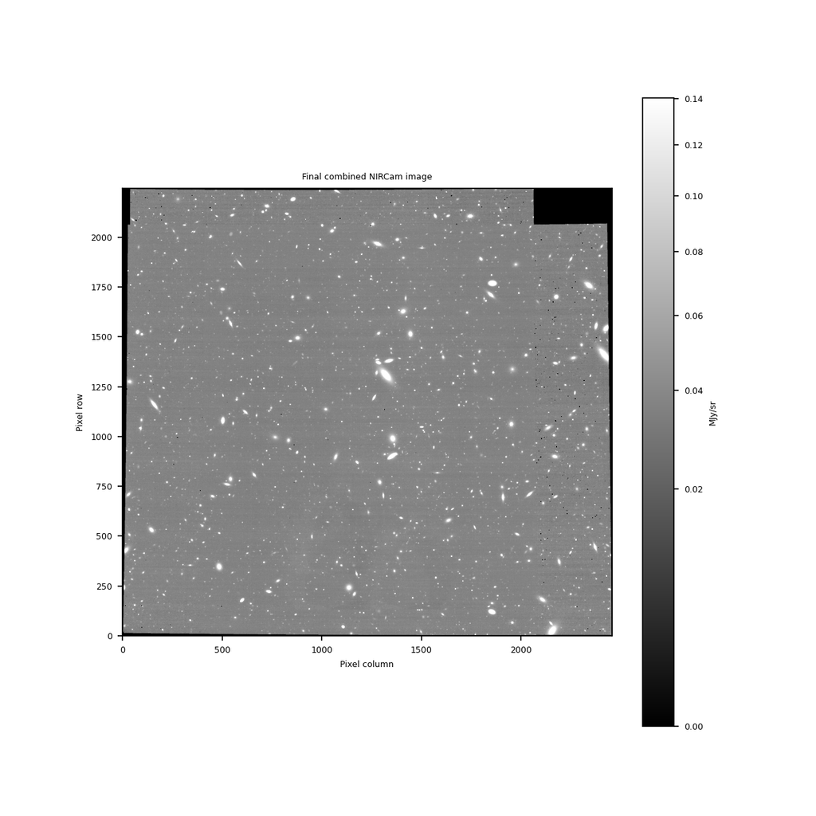

```python
create_image(combined_image.data, title="Final combined NIRCam image")
```

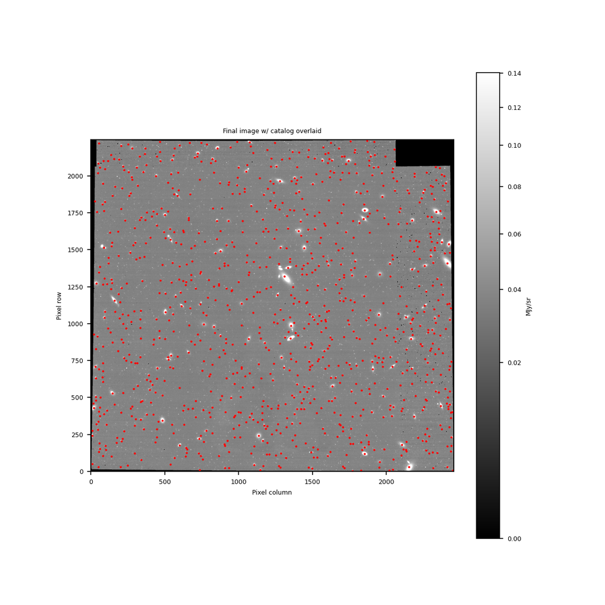

```python
create_image_with_cat(combined_image.data, catalog, title="Final image w/ catalog overlaid")
```

```python
catalog
```

*Table length=1017*

| label int64 | xcentroid float64 | ycentroid float64 | sky_centroid deg,deg SkyCoord | aper_bkg_flux Jy float64 | aper_bkg_flux_err Jy float64 | aper30_flux Jy float64 | aper30_flux_err Jy float64 | aper50_flux Jy float64 | aper50_flux_err Jy float64 | aper70_flux Jy float64 | aper70_flux_err Jy float64 | aper_total_flux Jy float64 | aper_total_flux_err Jy float64 | aper30_abmag float64 | aper30_abmag_err float64 | aper50_abmag float64 | aper50_abmag_err float64 | aper70_abmag float64 | aper70_abmag_err float64 | aper_total_abmag float64 | aper_total_abmag_err float64 | aper30_vegamag float64 | aper30_vegamag_err float64 | aper50_vegamag float64 | aper50_vegamag_err float64 | aper70_vegamag float64 | aper70_vegamag_err float64 | aper_total_vegamag float64 | aper_total_vegamag_err float64 | … |
| --- | --- | --- | --- | --- | --- | --- | --- | --- | --- | --- | --- | --- | --- | --- | --- | --- | --- | --- | --- | --- | --- | --- | --- | --- | --- | --- | --- | --- | --- | --- |
| 1 | 1768.4836 | 5.1823 | 215.01292413512527,52.90796778460386 | 0.000000e+00 | 3.284525e-11 | 5.071549e-06 | 2.072111e-08 | 7.496906e-06 | 2.428663e-08 | 7.919572e-06 | 2.484646e-08 | 1.158713e-05 | 3.635285e-08 | 22.137148 | 0.004427 | 21.712795 | 0.003512 | 21.653246 | 0.003401 | 21.240061 | 0.003401 | 19.313248 | 0.004427 | 18.888895 | 0.003512 | 18.829346 | 0.003401 | 18.416161 | 0.003401 | … |
| 2 | 1827.3504 | 6.6249 | 215.01121796826263,52.907991989927545 | 3.437622e-10 | 5.668194e-11 | 2.791016e-08 | 9.596304e-10 | 5.550757e-08 | 1.372515e-09 | 1.497520e-07 | 2.704136e-09 | 2.191022e-07 | 3.956421e-09 | 27.785594 | 0.036703 | 27.039119 | 0.026520 | 25.961568 | 0.019431 | 25.548383 | 0.019431 | 24.961694 | 0.036703 | 24.215219 | 0.026520 | 23.137668 | 0.019431 | 22.724483 | 0.019431 | … |
| 3 | 2017.5233 | 6.4405 | 215.00570621808836,52.90798533726272 | 3.099752e-10 | 6.131857e-11 | 1.704215e-08 | 8.122358e-10 | 3.514477e-08 | 1.183121e-09 | 1.121998e-07 | 2.547435e-09 | 1.641596e-07 | 3.727152e-09 | 28.321189 | 0.050551 | 27.535348 | 0.035949 | 26.275020 | 0.024375 | 25.861835 | 0.024375 | 25.497289 | 0.050551 | 24.711448 | 0.035949 | 23.451120 | 0.024375 | 23.037935 | 0.024375 | … |
| 4 | 2153.4319 | 30.1392 | 215.00176642524403,52.908396970794584 | 3.396681e-08 | 3.827207e-09 | 5.528315e-08 | 2.650732e-09 | 1.237814e-07 | 4.061311e-09 | 7.568703e-07 | 1.181986e-08 | 1.107377e-06 | 1.729364e-08 | 27.043518 | 0.050850 | 26.168361 | 0.035051 | 24.202446 | 0.016825 | 23.789261 | 0.016825 | 24.219618 | 0.050850 | 23.344461 | 0.035051 | 21.378546 | 0.016825 | 20.965361 | 0.016825 | … |
| 5 | 2448.9753 | 6.4927 | 214.99320150858597,52.907977521822055 | 0.000000e+00 | 8.063023e-11 | 6.214460e-09 | 8.965679e-10 | 1.378610e-08 | 1.333405e-09 | 6.491729e-08 | 2.881550e-09 | 9.498049e-08 | 4.215995e-09 | 29.416492 | 0.146322 | 28.551397 | 0.100240 | 26.869099 | 0.047155 | 26.455914 | 0.047155 | 26.592592 | 0.146322 | 25.727497 | 0.100240 | 24.045199 | 0.047155 | 23.632014 | 0.047155 | … |
| 6 | 1146.3285 | 11.3443 | 215.03095583823583,52.90808467345328 | 4.006067e-09 | 1.357924e-10 | 1.443991e-08 | 9.019450e-10 | 3.046291e-08 | 1.319177e-09 | 1.284160e-07 | 2.950584e-09 | 1.878854e-07 | 4.317000e-09 | 28.501089 | 0.065783 | 27.690572 | 0.046028 | 26.128452 | 0.024664 | 25.715267 | 0.024664 | 25.677189 | 0.065783 | 24.866672 | 0.046028 | 23.304552 | 0.024664 | 22.891367 | 0.024664 | … |
| 7 | 736.8464 | 10.2108 | 215.0428238485999,52.90806941326808 | 1.006129e-09 | 1.726238e-10 | 7.772828e-09 | 9.938725e-10 | 1.658454e-08 | 1.452303e-09 | 7.876436e-08 | 3.069877e-09 | 1.152401e-07 | 4.491537e-09 | 29.173552 | 0.130643 | 28.350741 | 0.091143 | 26.659176 | 0.041513 | 26.245991 | 0.041513 | 26.349652 | 0.130643 | 25.526841 | 0.091143 | 23.835276 | 0.041513 | 23.422091 | 0.041513 | … |
| 8 | 1495.3226 | 19.9268 | 215.0208407523125,52.90822987838456 | 3.056260e-09 | 2.518428e-10 | 3.214211e-08 | 1.123279e-09 | 6.486401e-08 | 1.612678e-09 | 2.177757e-07 | 3.255449e-09 | 3.186276e-07 | 4.763047e-09 | 27.632314 | 0.037296 | 26.869991 | 0.026664 | 25.554976 | 0.016110 | 25.141791 | 0.016110 | 24.808414 | 0.037296 | 24.046091 | 0.026664 | 22.731076 | 0.016110 | 22.317891 | 0.016110 | … |
| 9 | 2041.6502 | 15.1567 | 215.0050066776725,52.90813723800306 | 4.842202e-10 | 7.426582e-11 | 1.247170e-07 | 1.855495e-09 | 2.315915e-07 | 2.544946e-09 | 5.058471e-07 | 3.993633e-09 | 7.401048e-07 | 5.843084e-09 | 26.160186 | 0.016034 | 25.488194 | 0.011866 | 24.639952 | 0.008538 | 24.226767 | 0.008538 | 23.336286 | 0.016034 | 22.664294 | 0.011866 | 21.816052 | 0.008538 | 21.402867 | 0.008538 | … |
| ... | ... | ... | ... | ... | ... | ... | ... | ... | ... | ... | ... | ... | ... | ... | ... | ... | ... | ... | ... | ... | ... | ... | ... | ... | ... | ... | ... | ... | ... | … |
| 1008 | 1072.2993 | 2228.7241 | 215.033057115105,52.94684421824309 | 5.562159e-09 | 1.512789e-09 | 1.081380e-07 | 2.607493e-09 | 2.277315e-07 | 3.791033e-09 | 9.417839e-07 | 7.926766e-09 | 1.377924e-06 | 1.159765e-08 | 26.315054 | 0.025869 | 25.506442 | 0.017925 | 23.965122 | 0.009100 | 23.551937 | 0.009100 | 23.491154 | 0.025869 | 22.682542 | 0.017925 | 21.141222 | 0.009100 | 20.728037 | 0.009100 | … |
| 1009 | 667.0948 | 2223.4519 | 215.0448117323461,52.94675636613544 | 6.110077e-10 | 1.056072e-10 | 2.266607e-08 | 1.295939e-09 | 4.455815e-08 | 1.856439e-09 | 1.337632e-07 | 3.716479e-09 | 1.957089e-07 | 5.437580e-09 | 28.011560 | 0.060368 | 27.277682 | 0.044318 | 26.084159 | 0.029755 | 25.670974 | 0.029755 | 25.187660 | 0.060368 | 24.453782 | 0.044318 | 23.260259 | 0.029755 | 22.847074 | 0.029755 | … |
| 1010 | 1246.0386 | 2223.3863 | 215.0280172491411,52.9467487162071 | 3.837588e-10 | 5.163302e-11 | 7.306915e-09 | 9.605326e-10 | 1.462762e-08 | 1.393407e-09 | 4.782700e-08 | 3.032417e-09 | 6.997569e-08 | 4.436729e-09 | 29.240665 | 0.134093 | 28.487066 | 0.098792 | 27.200817 | 0.066746 | 26.787632 | 0.066746 | 26.416765 | 0.134093 | 25.663166 | 0.098792 | 24.376917 | 0.066746 | 23.963732 | 0.066746 | … |
| 1011 | 1622.5804 | 2224.2799 | 215.01709418853872,52.94675883541608 | 2.532051e-10 | 9.938636e-11 | 4.302554e-08 | 1.683693e-09 | 8.511120e-08 | 2.390118e-09 | 2.157455e-07 | 4.296072e-09 | 3.156572e-07 | 6.285583e-09 | 27.315684 | 0.041677 | 26.575033 | 0.030070 | 25.565146 | 0.021407 | 25.151961 | 0.021407 | 24.491784 | 0.041677 | 23.751133 | 0.030070 | 22.741246 | 0.021407 | 22.328061 | 0.021407 | … |
| 1012 | 988.4699 | 2229.7989 | 215.0354888934898,52.94686399186357 | 4.597347e-10 | 9.606254e-11 | 3.724387e-07 | 4.573064e-09 | 6.878093e-07 | 6.213571e-09 | 1.258425e-06 | 8.539799e-09 | 1.841201e-06 | 1.249458e-08 | 24.972363 | 0.013250 | 24.306330 | 0.009764 | 23.650432 | 0.007343 | 23.237247 | 0.007343 | 22.148463 | 0.013250 | 21.482430 | 0.009764 | 20.826532 | 0.007343 | 20.413347 | 0.007343 | … |
| 1013 | 746.8195 | 2225.7715 | 215.0424989715388,52.94679615622074 | 3.080907e-10 | 7.456691e-11 | 4.860495e-08 | 1.717242e-09 | 8.636427e-08 | 2.324777e-09 | 1.561245e-07 | 3.733427e-09 | 2.284258e-07 | 5.462377e-09 | 27.183299 | 0.037698 | 26.559165 | 0.028840 | 25.916322 | 0.025658 | 25.503137 | 0.025658 | 24.359399 | 0.037698 | 23.735265 | 0.028840 | 23.092422 | 0.025658 | 22.679237 | 0.025658 | … |
| 1014 | 1756.7968 | 2234.5398 | 215.01320044097395,52.946935970723274 | 2.040955e-09 | 1.866223e-10 | 2.331399e-08 | 1.395385e-09 | 4.963145e-08 | 2.057823e-09 | 2.002689e-07 | 4.434638e-09 | 2.930133e-07 | 6.488319e-09 | 27.980958 | 0.063113 | 27.160607 | 0.044109 | 25.645966 | 0.023780 | 25.232781 | 0.023780 | 25.157058 | 0.063113 | 24.336708 | 0.044109 | 22.822066 | 0.023780 | 22.408882 | 0.023780 | … |
| 1015 | 1917.0651 | 2230.6043 | 215.00855134342814,52.94686438438994 | -4.097819e-11 | 9.295229e-11 | 6.908440e-09 | 9.542798e-10 | 1.407632e-08 | 1.411563e-09 | 5.383949e-08 | 3.429753e-09 | 7.877256e-08 | 5.018072e-09 | 29.301550 | 0.140482 | 28.528777 | 0.103757 | 27.072248 | 0.067051 | 26.659063 | 0.067051 | 26.477650 | 0.140482 | 25.704877 | 0.103757 | 24.248348 | 0.067051 | 23.835163 | 0.067051 | … |
| 1016 | 468.2817 | 2232.6935 | 215.05057894834997,52.946919592191804 | 4.613320e-10 | 8.282532e-11 | 8.610907e-09 | 9.628384e-10 | 1.892669e-08 | 1.428148e-09 | 6.869205e-08 | 3.003985e-09 | 1.005033e-07 | 4.395130e-09 | 29.062378 | 0.115082 | 28.207313 | 0.078982 | 26.807734 | 0.046472 | 26.394549 | 0.046472 | 26.238478 | 0.115082 | 25.383413 | 0.078982 | 23.983834 | 0.046472 | 23.570649 | 0.046472 | … |
| 1017 | 1869.9143 | 2236.6488 | 215.00991895995816,52.94697087986899 | 1.540192e-09 | 1.766420e-10 | 9.626881e-09 | 1.098776e-09 | 2.104611e-08 | 1.880918e-09 | 9.617718e-08 | 5.622810e-09 | 1.407168e-07 | 8.226733e-09 | 28.941286 | 0.117346 | 28.092070 | 0.092940 | 26.442320 | 0.061689 | 26.029135 | 0.061689 | 26.117386 | 0.117346 | 25.268170 | 0.092940 | 23.618420 | 0.061689 | 23.205235 | 0.061689 | … |

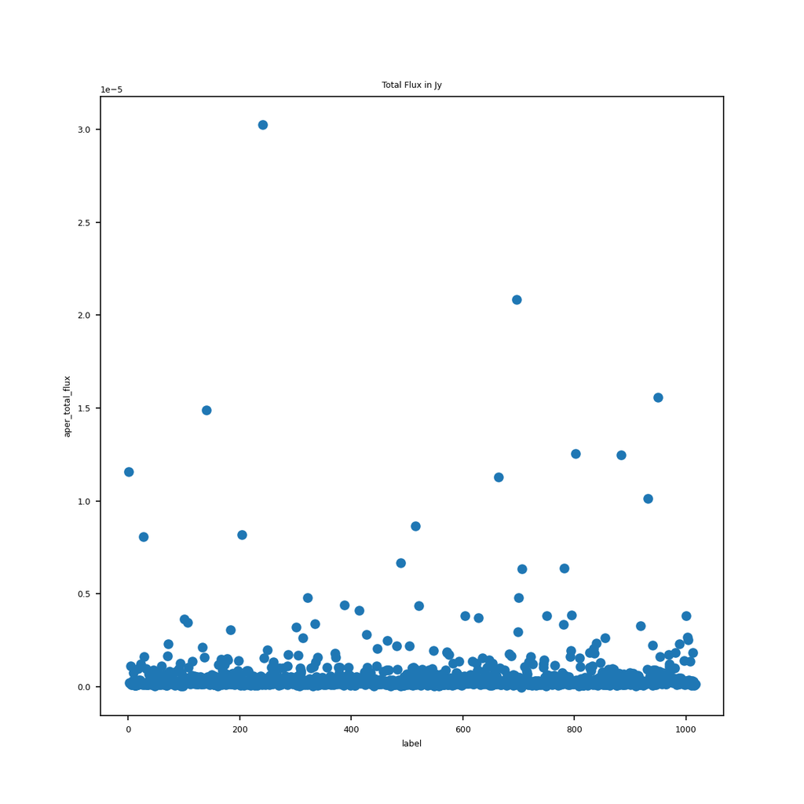

```python
create_scatterplot(catalog['label'], catalog['aper_total_flux'],title='Total Flux in '+str(catalog['aper_total_flux'].unit))
```

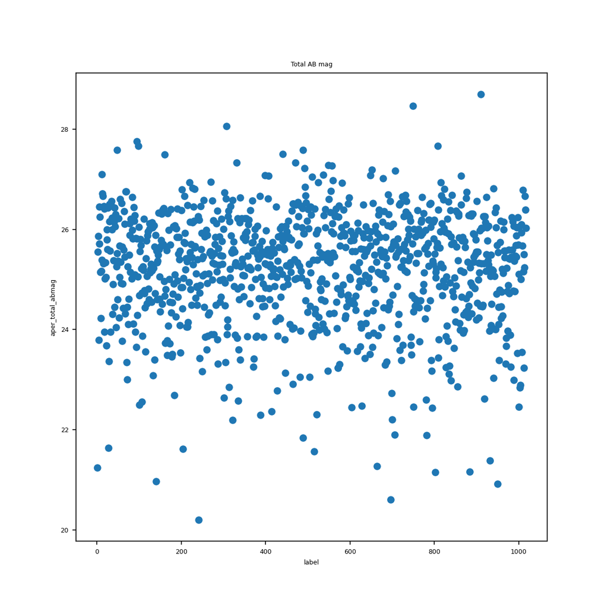

```python
create_scatterplot(catalog['label'], catalog['aper_total_abmag'],title='Total AB mag')
```

Top of Page

# Manually Find Matches

Since this is a simulated data set, we can compare the output catalog information from the pipeline with the input catalog information used to create the simulation. Grab the input catalog RA, Dec values and the output catalog RA, Dec values.

```python
test_outputs = get_input_table(file_names[4])
in_ra = test_outputs['In_RA'].data
in_dec = test_outputs['In_Dec'].data
out_ra = catalog['sky_centroid'].ra.deg
out_dec = catalog['sky_centroid'].dec.deg
```

Set the tolerance and initialize our counters.

```python
tol = 1.e-3
found_count=0
multiples_count=0
missed_count=0
```

Below we loop through the input RA, Dec values and compare them to the RA, Dec values in the output catalog. For cases where there are multiple matches for our tolerance level, count those cases.

```python
for ra,dec,idx in zip(in_ra, in_dec,range(len(test_outputs))):

    match = np.where((np.abs(ra-out_ra) < tol) & (np.abs(dec-out_dec) < tol))

    if np.size(match) == 1:
        found_count +=1
        test_outputs['Detected'][idx] = 'Y'
        test_outputs['Out_RA'][idx] = out_ra[match]
        test_outputs['Out_Dec'][idx] = out_dec[match]
        test_outputs['RA_Diff'][idx] = np.abs(ra-out_ra[match])
        test_outputs['Dec_Diff'][idx] = np.abs(dec-out_dec[match])

    if np.size(match) > 1:
        multiples_count +=1

    if np.size(match) < 1:
        missed_count +=1
```

Let's see how it did.

```python
total_percent_found = (found_count/len(test_outputs))*100

print('\n')
print('SNR threshold used for pipeline: ',img3.source_catalog.snr_threshold)
print('Total found:',found_count)
print('Total missed:',missed_count)
print('Number of multiples: ',multiples_count)
print('Total number of input sources:',len(test_outputs))
print('Total number in output catalog:',len(catalog))
print('Total percent found:',total_percent_found)
print('\n')
```

```
SNR threshold used for pipeline:  5
Total found: 6660
Total missed: 4815
Number of multiples:  8020
Total number of input sources: 19495
Total number in output catalog: 1017
Total percent found: 34.162605796358044
```

### Use photutils to find catalog matches

```python
catalog_in = SkyCoord(ra=in_ra*u.degree, dec=in_dec*u.degree)
catalog_out = SkyCoord(ra=out_ra*u.degree, dec=out_dec*u.degree)
```

```python
max_sep = 1.0 * u.arcsec
```

```python
# idx, d2d, d3d = cat_in.match_to_catalog_3d(cat_out)
idx, d2d, d3d = catalog_in.match_to_catalog_sky(catalog_out)
sep_constraint = d2d < max_sep
catalog_in_matches = catalog_in[sep_constraint]
catalog_out_matches = catalog_out[idx[sep_constraint]]
```

Now, `catalog_in_matches` and `catalog_out_matches` are the matched sources in `catalog_in` and `catalog_out`, respectively, which are separated less than our `max_sep` value.

```python
print('Number of matched sources using max separation of '+str(max_sep)+': ',len(catalog_out_matches))
```

```
Number of matched sources using max separation of 1.0 arcsec:  3416
```

## About this Notebook

**Author:** Alicia Canipe, Senior Staff Scientist, NIRCam  
**Updated On:** 05/26/2021

Top of Page

[figure not shown]